# Tutoriel / Créer un thème MapContrib

### Représentation

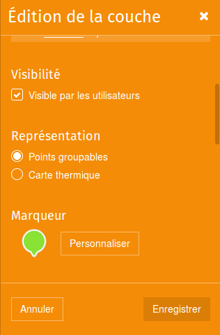

Création couches - Partie 4

Dans l’édition de la couche, la possibilité de personnaliser la `Représentation` sous forme de `Points groupables` (“clustering” par défaut) ou de `Carte thermique` (avec quelques options disponibles).

[figure not shown]

[figure not shown]

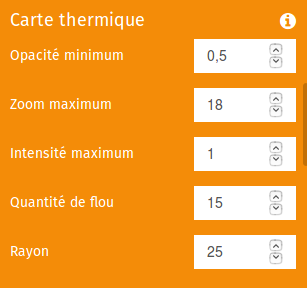

### Marqueur

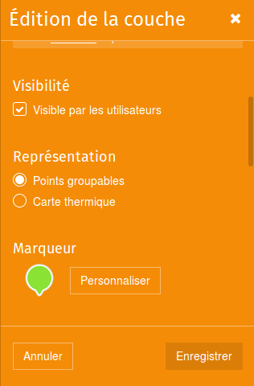

Création couches - Partie 4

Les `marqueurs` de chaque couche sont personnalisables : - au niveau de la couleur et de la forme, - avec une bibliothèque d’icônes, - avec un lien vers une image extérieure (assurez vous d’avoir les droits d’utilisation de l’image),

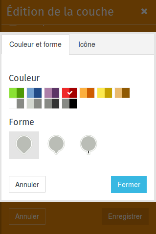

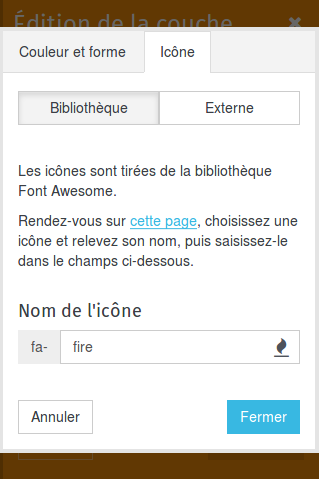

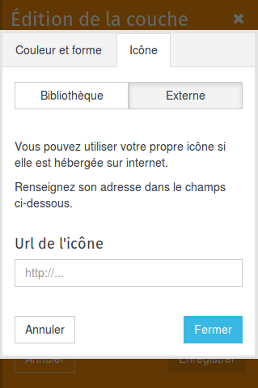

### Contenu des bulles

Pour chaque couche, les informations associées peuvent être personnalisées. Pour cela, il faut définir le `Contenu des bulles` (le markdown est supporté).

De plus, quelque soit la source (overpass, csv, GeoJSON, GPX), les données peuvent être affichées de manière dynamique, en utilisant une clé entre accolade : {clé}.

La clé peut-être “l’en-tête” de colonne du fichier csv ou la clé du couple clé/valeur de l’ontologie OpenStreetMap.

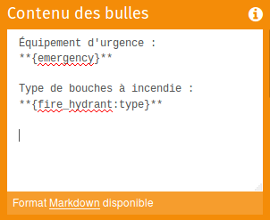

[figure not shown]

### Couche requête overpass

Dans le cas d’une couche de type overpass, plusieurs autres personnalisations sont possibles.

#### Zoom minimum, Requête OverPass et Cache

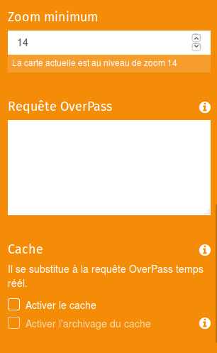

Couche overpass - Partie 1

- `Zoom minimum` / définit la valeur à laquelle la requête overpass se déclenche,
- `Requête OverPass` / Zone pour l’exécution de la requête
  - le temps de requête maximum (timeout) est limité à 120 secondes,
  - la taille maximale de données rapatriés est limitée à 1 Mo !
- `Le cache`
  - activer le cache présente des avantages et des inconvénients
    - les données se chargent plus rapidement (la requête overpass n’est pas exécutée, les données sont téléchargées depuis leur stockage en cache sur nos serveurs) mais se mettent à jour moins régulièrement (la requête est relancée une fois par jour pour mise à jour),
    - sur un thème dont le cache est activé, une étoile jaune signale l’ajout d’une donnée depuis le thème aux autres utilisateurs du thème,

### Tester sa requête

Selon le zoom minimum défini, la requête peut ne pas se déclencher à l’ouverture du thème. Il faudra alors zoomer pour permettre le déclenchement.

[figure not shown]

[figure not shown]

[figure not shown]

### Cas des autres formats de fichiers (csv, GeoJSon, GPX))

`Nom, Description, Visibilité, Représentation (groupable ou thermique), Marqueur et Contenu des bulles` fonctionnent de la même manière. Cependant les données importées ne seront ni modifiables, ni déplaçables et n’ont pas d’interactions avec la base de données OpenStreetMap.

Ces données importées peuvent ainsi être comparées aux données OpenStreetMap.

#### CSV, GeoJSON, GPX

Quelques contraintes : - le poids des fichiers ne doit pas dépasser 2 MB, - dans le cas du fichier csv, les colonnes de localisation doivent être nommées latitude et longitude,

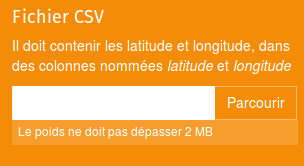

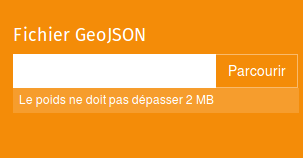

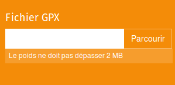

## Configurer ses tags

La configuration des tags va permettre par la suite de les utiliser : - pour la traduction des types de noeuds (“modèles” / “presets”) : voir paragraphe suivant) - pour l’appel dynamique dans les bulles (“pop-ups”) et donc pour la traduction dans les données dynamiques : cela permet ainsi d’avoir une interface sans aucun mot étranger (souvent un frein pour les contributeurs ni geek ni cartographe ni contributeur).

Vous pouvez créer autant de tags que nécessaire, cependant n’oubliez pas de garder le lien avec la requête overpass… Bien “penser” ce que l’on veut voir, améliorer, ajouter avant de se lancer dans la requête, les tags, les modèles, la traduction !

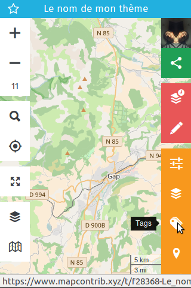

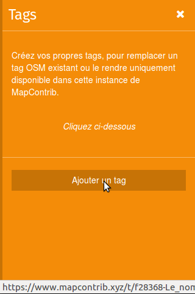

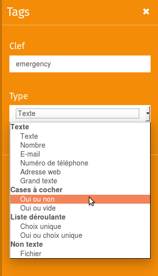

- `Type` / permet de définir différents formats que l’on retrouvera ensuite dans les **Types de noeuds** et différentes présentations !
  - Cases à cocher
  - liste déroulante avec traduction

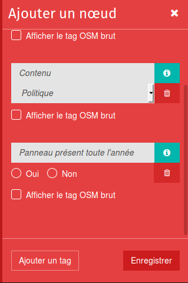

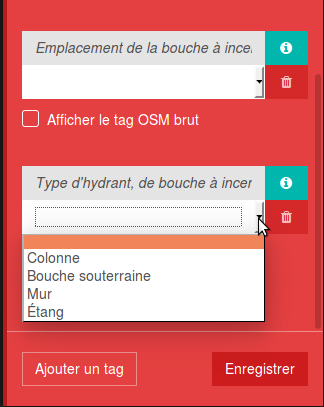

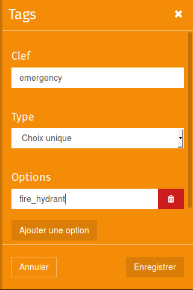

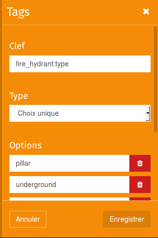

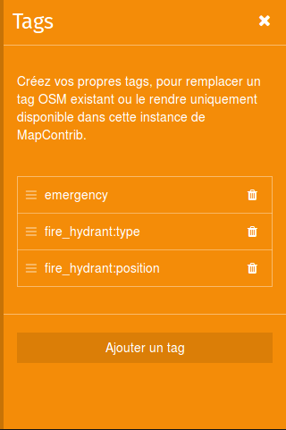

## Définir les types de noeuds, “modèles”

Les types de noeuds permettent de définir à la fois : - les tags pré-remplis qui pourront être utilisés pour compléter, qualifier des données existantes (fusion des tags entre le noeud existant et le type de noeud), - les tags pré-remplis qui pourront être ajoutés lorsque un noeud est manquant,

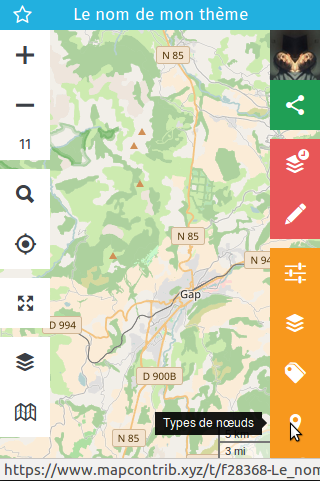

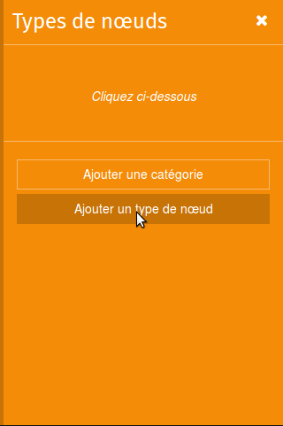

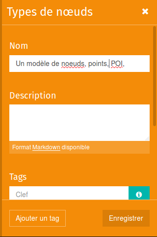

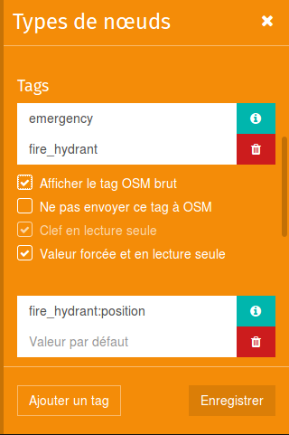

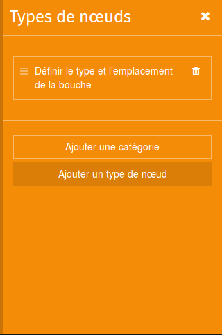

Cela se traduit donc pour le contributeur en un noeud “pré-rempli” :

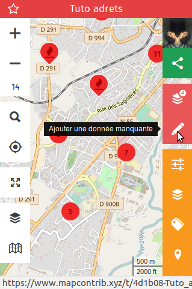

[figure not shown]

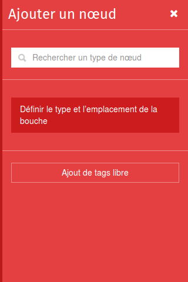

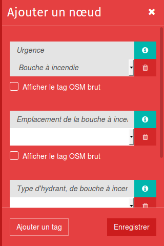

## Traduire son thème

Après avoir rempli l’ensemble des informations il est possible de traduire les thèmes pour qu’il soit adapté en fonction de la langue du navigateur.

L’absence de traduction d’une langue entraîne l’utilisation des chaînes de caractères par défaut. Par défaut remplir les champs comme indiqué ci-dessus, puis traduire seulement les éléments nécessaires / souvent **tags** !).

Si vous avez écrit en français sauf les tags, il n’est pas nécessaire de remplir les éléments de traduction concernant la configuration générale, les couches ou les types de noeuds. En l’absence de traductions, ceux sont les contenus écrit initiaux qui sont affichés.

Ces traductions seront cependant nécessaires pour que cela fonctionne dans d’autres langues.

[figure not shown]

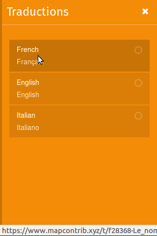

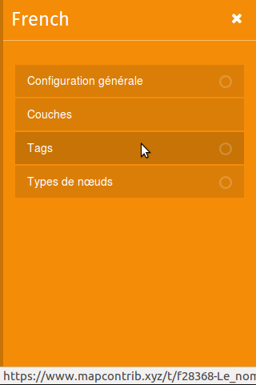

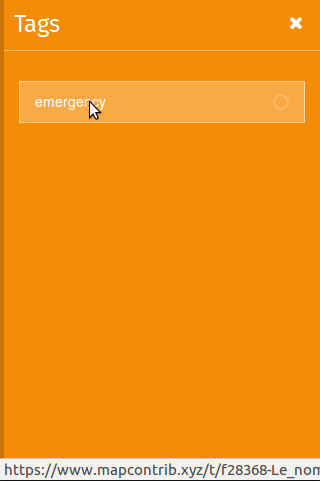

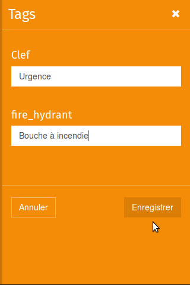

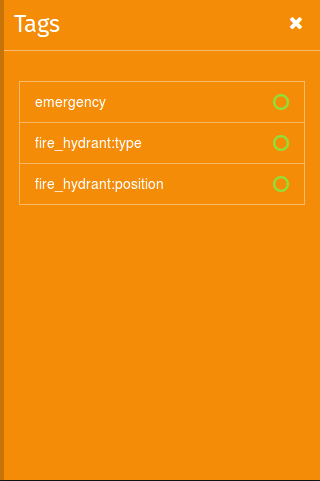

## Quelques exemples de thèmes

- n’oubliez pas que vous pouvez dupliquer un thème, en devenir “administrateur” et ainsi pouvoir le disséquer pour comprendre,

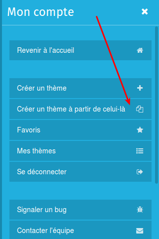

[figure not shown]

[figure not shown]

- les bornes à incendies,
- les bornes de recyclages,
- …

## Quelques ressources complémentaires

### La requête overpass-turbo

### Écrire en markdown

- https://fr.wikipedia.org/wiki/Markdown